# Chap10.3-10.4

Mijeong Kim

```r
library(tsibble)
library(tsibbledata)
library(tibble)
library(dplyr)
library(knitr)
library(ggplot2)
library(fpp3)
library(fpp2)
library(seasonal)
library(feasts)
```

## 10.3 예측 (Forecasting)

ARIMA 오차를 포함한 회귀모형으로 예측하려면,

1. 회귀 부분의 예측
2. ARIMA 오차 항의 예측 → 이 두 가지를 결합해야 한다.
- **설명 변수(x)**가 미래에도 알려져 있다면(예: 요일, 시간 등), 예측은 간단하다.
- 하지만 미래의 x 값이 미지일 경우,
  - 별도로 x를 모델링하거나
  - 미래 값을 가정하여 예측해야 한다.

### Example: US Personal Consumption and Income

- 향후 8분기 예측을 수행함
- 가정: 향후 가처분 소득의 변화율은 최근 40년 평균 변화율과 같다고 설정함

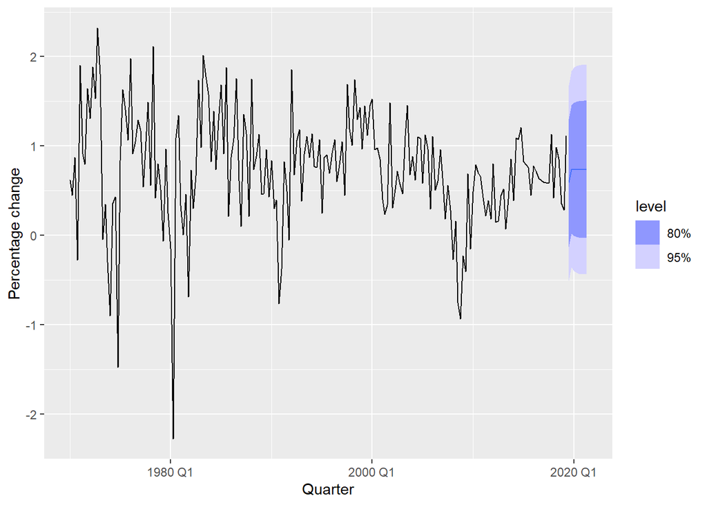

```r
fit <- us_change |>
  model(ARIMA(Consumption ~ Income))

us_change_future <- new_data(us_change, 8) |>
  mutate(Income = mean(us_change$Income))
forecast(fit, new_data = us_change_future) |>
  autoplot(us_change) +
  labs(y = "Percentage change")
```

Figure 10.4: Forecasts obtained from regressing the percentage change in consumption expenditure on the percentage change in disposable income, with an ARIMA(1,0,2) error model.

- **소득 변수(예측 변수)**를 포함한 모델은 일부 변동을 설명할 수 있으므로, 예측 구간이 단순 ARIMA 모델보다 좁게 나타남
- 하지만 회귀모형의 예측 구간(ARIMA 오차 포함 여부와 무관)은 예측 변수의 불확실성은 반영하지 않음

→ 따라서 예측 구간은 주어진(또는 가정된) 예측 변수 값에 조건부임을 명확히 인식해야 한다.

### Example: Forecasting electricity demand

일일 전기 수요는 기온의 함수로 모델링할 수 있다.

- 추운 날에는 난방, 더운 날에는 냉방으로 전기 사용량이 증가하며, 이는 전기 요금 고지서에서도 확인할 수 있다.
- 이러한 경향은 기온이 낮거나 높을수록 수요가 증가하는 형태로 나타나며, 그림 10.5의 U자형 곡선에서 확인할 수 있다.

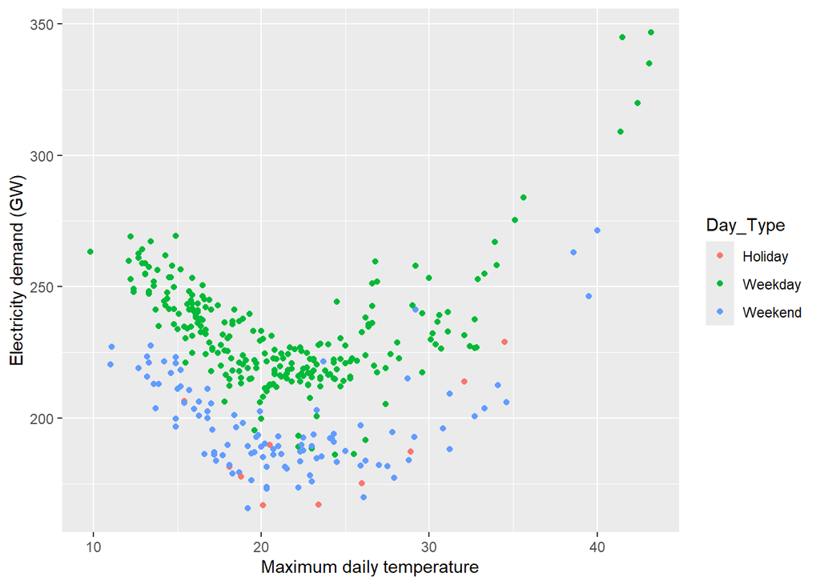

```r
vic_elec_daily <- vic_elec |>
  filter(year(Time) == 2014) |>
  index_by(Date = date(Time)) |>
  summarise(
    Demand = sum(Demand) / 1e3,
    Temperature = max(Temperature),
    Holiday = any(Holiday)
  ) |>
  mutate(Day_Type = case_when(
    Holiday ~ "Holiday",
    wday(Date) %in% 2:6 ~ "Weekday",
    TRUE ~ "Weekend"
  ))

vic_elec_daily |>
  ggplot(aes(x = Temperature, y = Demand, colour = Day_Type)) +
  geom_point() +
  labs(y = "Electricity demand (GW)",
       x = "Maximum daily temperature")
```

Figure 10.5: Daily electricity demand versus maximum daily temperature for the state of Victoria in Australia for 2014.

vic_elec_daily 데이터에는

- 일일 총 전력 수요
- 일일 최고 기온
- 공휴일 여부를 나타내는 지시 변수 가 포함되어 있다.

이 예제에서는 ARIMA() 함수를 사용하여 **ARMA 오차를 포함한 이차 회귀모형(quadratic regression model)**을 적합한다.

또한, 해당 날짜가 평일(근무일)인지 여부를 나타내는 지시 변수도 모델에 포함된다.

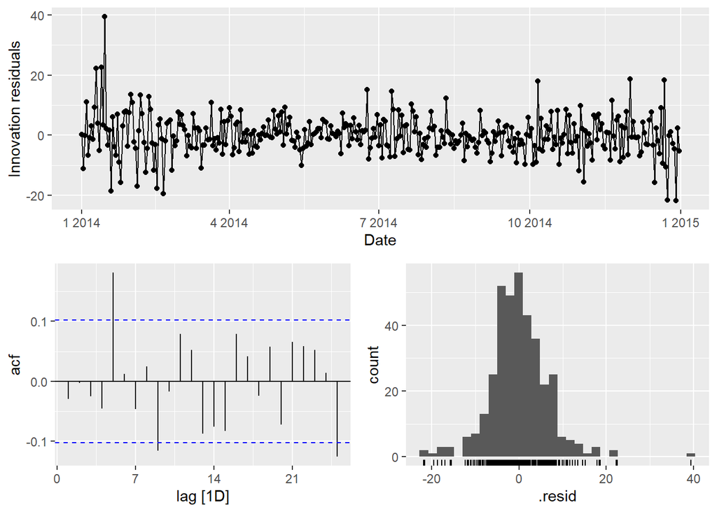

```r
fit <- vic_elec_daily |>
  model(ARIMA(Demand ~ Temperature + I(Temperature^2) +
                (Day_Type == "Weekday")))
fit |> gg_tsresiduals()
```

Figure 10.7: Residuals diagnostics for a dynamic regression model for daily electricity demand with workday and quadratic temperature effects.

```r
augment(fit) |>
  features(.innov, ljung_box, dof = 6, lag = 14)
```

```
## # A tibble: 1 × 3
##   .model                                                       lb_stat lb_pvalue
##   <chr>                                                          <dbl>     <dbl>
## 1 "ARIMA(Demand ~ Temperature + I(Temperature^2) + (Day_Type …    28.4  0.000404
```

**잔차에 이분산성(heteroscedasticity)**이 존재함:

- 1~2월에 분산이 큼, 5월에는 작음
- 잔차의 자기상관과 긴 꼬리를 가진 분포도 관찰됨 → 이러한 문제들은 예측 구간의 신뢰도에 영향을 줄 수 있지만, 점 예측 자체는 여전히 유효
- 예측 시점: 2015년 1월 1일 목요일부터 14일간 (이 날은 공휴일로 비근무일)
- 실제로는 기상청의 14일간 온도 예측값을 사용할 수 있지만, 예제에서는 **시나리오 기반 예측(Section 7.6)**을 적용해 14일 동안의 기온을 26도로 고정하여 예측을 수행함

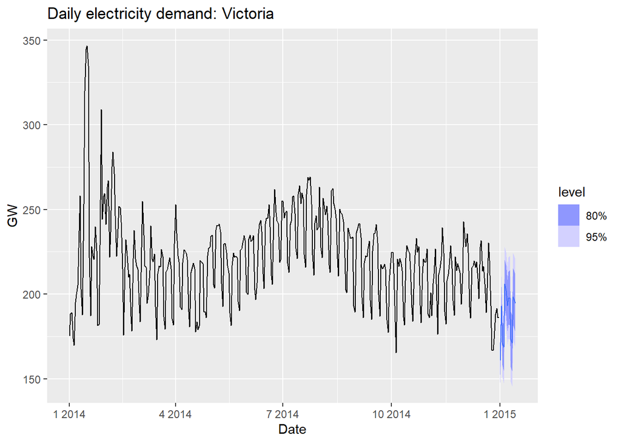

```r
vic_elec_future <- new_data(vic_elec_daily, 14) |>
  mutate(
    Temperature = 26,
    Holiday = c(TRUE, rep(FALSE, 13)),
    Day_Type = case_when(
      Holiday ~ "Holiday",
      wday(Date) %in% 2:6 ~ "Weekday",
      TRUE ~ "Weekend"
    )
  )
forecast(fit, vic_elec_future) |>
  autoplot(vic_elec_daily) +
  labs(title="Daily electricity demand: Victoria",
       y="GW")
```

Figure 10.8: Forecasts from the dynamic regression model for daily electricity demand. All future temperatures have been set to 26 degrees, and the working day dummy variable has been set to known future values.

- 2015년 초 2주간의 점 예측 결과는 전반적으로 타당하게 보임
- 이는 2014년 말 전력 수요 감소(여름 휴가로 인한 영향)를 반영한 것으로, 예측된 수요 역시 낮은 수준으로 나타남

## 10.4 Stochastic and deterministic trends

#### 결정론적 추세 (Deterministic Trend)

- 회귀 모델로 표현:

$$y_t = \beta_0 + \beta_1 t + \eta_t$$

- 여기서 $\eta_t$는 **ARMA 과정**을 따름
- 추세는 **고정된 기울기(β₁)**를 가지며, 시간에 따라 일정하게 증가 또는 감소함

#### 확률론적 추세 (Stochastic Trend)

- 동일한 형태로 시작하지만 $\eta_t$는 **ARIMA 과정(d=1)**을 따름:

$$y_t = \beta_0 + \beta_1 t + \eta_t$$

- 양변을 차분하면:

$$y'_t = \beta_1 + \eta'_t, \quad \text{where } \eta'_t \sim
ARMA$$

- 다시 쓰면:

$$y_t = y_{t-1} + \beta_1 + \eta'_t$$

- 이는 **drift가 있는 랜덤 워크(random walk with drift)**와 유사하지만, 오차항이 **백색잡음이 아닌 ARMA 과정**

#### 두 모델의 차이점

| 항목 | 결정론적 추세 | 확률론적 추세 |
| --- | --- | --- |
| 추세의 본질 | 일정한 증가/감소 | 확률적으로 변동하는 경향 |
| 오차 구조 | ARMA | ARIMA (보통 d=1) |
| 차분 필요 여부 | 없음 | 1차 차분 필요 |
| 예측 특성 | 비교적 안정된 예측 | 예측 불확실성이 증가함 |

### Example: Air transport passengers Australia

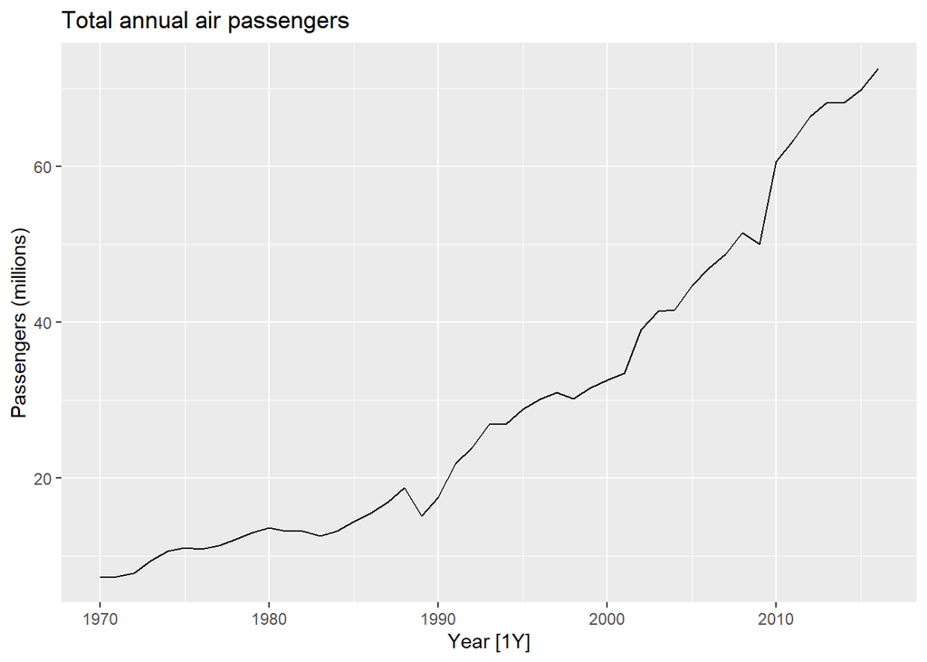

```r
aus_airpassengers |>
  autoplot(Passengers) +
  labs(y = "Passengers (millions)",
       title = "Total annual air passengers")
```

Figure 10.9: Total annual passengers (in millions) for Australian air carriers, 1970–2016.

그림 10.9는 1970년부터 2016년까지의 호주 항공 여객 수 총합을 연도별로 보여준다. 이 데이터에 대해 결정론적 추세 모델과 확률론적 추세 모델을 각각 적합할 예정이다.

먼저, 결정론적 추세 모델은 아래와 같은 방식으로 적합한다.

```r
fit_deterministic <- aus_airpassengers |>
  model(deterministic = ARIMA(Passengers ~ 1 + trend() +
                                pdq(d = 0)))
report(fit_deterministic)
```

```
## Series: Passengers
## Model: LM w/ ARIMA(1,0,0) errors
##
## Coefficients:
##          ar1  trend()  intercept
##       0.9564   1.4151     0.9014
## s.e.  0.0362   0.1972     7.0751
##
## sigma^2 estimated as 4.343:  log likelihood=-100.88
## AIC=209.77   AICc=210.72   BIC=217.17
```

결정론적 추세 모델은 다음과 같이 표현된다:
$$\begin{aligned}
y_t &= 0.901 + 1.415t + \eta_t \\
\eta_t &= 0.956 \eta_{t-1} + \varepsilon_t \\
\varepsilon_t &\sim \text{NID}(0,\ 4.343)
\end{aligned}$$
→ 추정된 연간 방문객 증가 추세는 약 1.42백만 명

이와는 대조적으로, 확률론적 추세 모델도 추정할 수 있다.

```r
fit_stochastic <- aus_airpassengers |>
  model(stochastic = ARIMA(Passengers ~ pdq(d = 1)))
report(fit_stochastic)
```

```
## Series: Passengers
## Model: ARIMA(0,1,0) w/ drift
##
## Coefficients:
##       constant
##         1.4191
## s.e.    0.3014
##
## sigma^2 estimated as 4.271:  log likelihood=-98.16
## AIC=200.31   AICc=200.59   BIC=203.97
```

해당 모델은 다음과 같이 표현된다:

$$y_t - y_{t-1} = 1.419 + \varepsilon_t$$

또는 누적 형태로 쓰면:

$$\begin{aligned}
y_t &= y_0 + 1.419 t + \eta_t\\
\eta_t &= \eta_{t-1} + \varepsilon_t,\\
\varepsilon_t &\sim \text{NID}(0,\ 4.271)
\end{aligned}$$

#### 해석

- 추정된 **연간 방문객 증가 추세**는 **약 1.42백만 명**으로,  
  앞서 추정한 **결정론적 모델**과 유사함

#### 예측 구간 차이

- 예측 중심값은 유사하지만, **예측 구간은 큰 차이**
- **그림 10.10**에서 확인할 수 있듯이,  
  **확률론적 추세 모델은 비정상성 때문에 예측 구간이 훨씬 넓음**

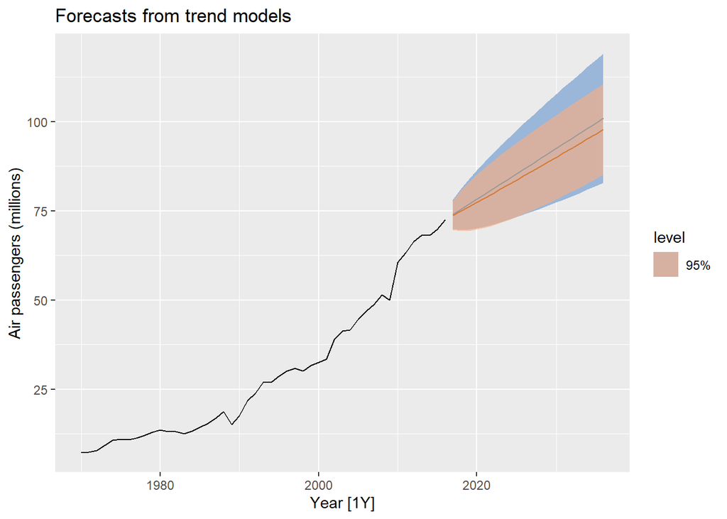

```r
aus_airpassengers |>
  autoplot(Passengers) +
  autolayer(fit_stochastic |> forecast(h = 20),
    colour = "#0072B2", level = 95) +
  autolayer(fit_deterministic |> forecast(h = 20),
    colour = "#D55E00", alpha = 0.65, level = 95) +
  labs(y = "Air passengers (millions)",
       title = "Forecasts from trend models")
```

Figure 10.10: Forecasts of annual passengers for Australian air carriers using a deterministic trend model (orange) and a stochastic trend model (blue).

결정론적 추세 모델은 추세의 기울기(성장률)가 시간에 따라 변하지 않는다는 암묵적 가정을 포함한다. 반면, 확률론적 추세 모델은 추세가 변화할 수 있으며, 추정된 성장률은 과거 평균일 뿐 미래에도 동일하다는 보장은 없다.

→ 따라서 장기 예측일수록 확률론적 추세 모델이 더 안전하며, 예측 구간이 미래 성장의 불확실성을 반영할 수 있어 유리하다.